# Corona - Fallzahlenauswertung

### Datenquelle, Abrufzeitpunkt

| Amtliche RKI-Corona-Daten für Land-/Stadtkreis | Abrufzeitpunkt |
| --- | --- |
| Nürnberg, kreisfreie Stadt | Mittwoch, 03.03.2021, 13:25:24 |

### Inzidenzrelevanter Zeitraum

| von - bis | nicht mehr in der Inzidenzzahl |
| --- | --- |
| Mi, 24.02.2021 - Di, 02.03.2021 | Di, 23.02.2021 und älter |

### Veränderungen zum Vortag

```
##   Meldedatum    Art Fallzahl Inzidenzrelevant
## 1 2021-02-19 Storno       -1             Nein
## 2 2021-02-21 Storno       -1             Nein
## 3 2021-02-24 Storno       -2               Ja
## 4 2021-02-27 Storno       -3               Ja
## 5 2021-03-01    Neu        4               Ja
## 6 2021-03-02    Neu       31               Ja
```

### Wochenübersicht

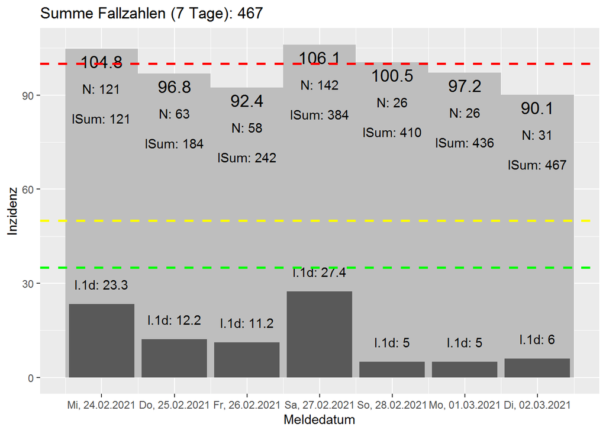

Erläuterung der Zahlenangaben:  
**N**: Anzahl der neu und nachträglich gemeldeten abzüglich der gestrichenen Fälle des jeweiligen Tages  
**I.1d** (“1-Tages-Inzidenz”): Höhe des Beitrags, den dieser Tag zur Wocheninzidenz leistet  
**lSum**: Aggregierte Summe der Fallzahlen über den Verlauf der beobachteten Woche. Der erste Tag entspricht diesem einzelnen Tag (und fällt als nächstes aus der Inzidenz), der letzte Tag entspricht der Wochen-Inzidenz.

### Über-/Unterschreitungen der geltenden Grenzwerte

```
##   Grenzwert bei_Fallzahl Abweichung
## 1        35          181       +286
## 2        50          259       +208
## 3       100          518        -51
```

### Gesicherter Ausblick (absehbare Streichungen)

Aktuelle Inzidenz: 90.1, basierend auf den insgesamt 467 Fällen der letzten Woche.

[output not shown]

Die Fallzahlen der nächsten Tage sowie eventuelle Nachmeldungen sind dabei nicht vorhersehbar. Der maximale Rückgang wird nur erreicht, wenn bis zu diesem Tag per Saldo kein neuer Fall erfasst wird.

### Ungesicherter Ausblick

Fallzahlen gehen je nach Wochentag in unterschiedlicher Höhe ein. Basierend auf den letzten 3 Wochen bzw. 21 Tagen ergibt sich folgende Verteilung:

```
##    Wochentag Fallzahl_Durchschnitt DoW
## 1    Sonntag                 43.33   1
## 2     Montag                 37.33   2
## 3   Dienstag                 49.67   3
## 4   Mittwoch                102.33   4
## 5 Donnerstag                 75.67   5
## 6    Freitag                 75.67   6
## 7    Samstag                 83.67   7
```

…auf der Grundlage folgender Fallzahlen der letzten 3 Wochen:

```
##    Meldedatum AnzahlFall  Wochentag
## 1  2021-02-10         81   Mittwoch
## 2  2021-02-11         60 Donnerstag
## 3  2021-02-12         88    Freitag
## 4  2021-02-13         38    Samstag
## 5  2021-02-14         49    Sonntag
## 6  2021-02-15         43     Montag
## 7  2021-02-16         50   Dienstag
## 8  2021-02-17        105   Mittwoch
## 9  2021-02-18        104 Donnerstag
## 10 2021-02-19         81    Freitag
## 11 2021-02-20         71    Samstag
## 12 2021-02-21         55    Sonntag
## 13 2021-02-22         43     Montag
## 14 2021-02-23         68   Dienstag
## 15 2021-02-24        121   Mittwoch
## 16 2021-02-25         63 Donnerstag
## 17 2021-02-26         58    Freitag
## 18 2021-02-27        142    Samstag
## 19 2021-02-28         26    Sonntag
## 20 2021-03-01         26     Montag
## 21 2021-03-02         31   Dienstag
```

### Blick in die Kristallkugel

Hier werden drei verschiedene Szenarien dargestellt:  
* Optimisitsche Variante 0 (Grün): Es treten keine Fälle mehr auf, somit dauert es noch 7 Tage, bis alle Inzidenzfälle abgeschmolzen sind.  
* Realistische Variante 1 (schwarz): Täglich kommen die durchschnittlichen Fälle für den jeweiligen Wochentag hinzu, was dem Abschmelzen aus Variante 0 entgegenwirkt.  
* Pessimistische Variante 2 (Rot): Wie Variante 1, nur kommt täglich der DOPPELTE Durchschnitt für den jeweiligen Wochentag hinzu. Dieser Zuwachs stellt keineswegs das obere Limit des möglichen dar.

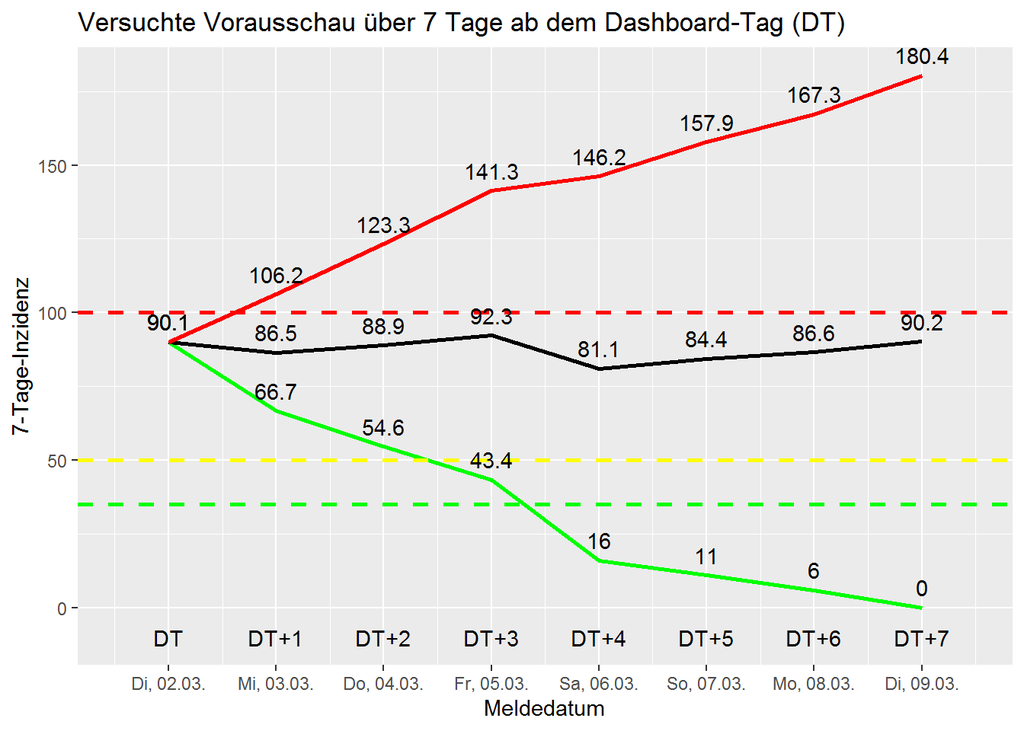